# Antenatal, and Intranatal care Utilization in Turkey using DHS data 2013

Sami Najmaddin Saeed

2026-01-03

## 1 Introduction:

### 1.1 Background

An important measure of a country’s overall healthcare progress and social justice is maternal health. According to the World Health Organization (WHO), reducing maternal and neonatal morbidity and mortality requires comprehensive maternal care, including competent attendance at birth and adequate prenatal care (ANC). Data from the 2013 Turkey Demographic and Health Survey (TDHS) show that substantial internal disparities persist within the Turkish population, despite international initiatives that have significantly expanded access to these services.

### 1.2 General objective:

To describe antenatal and intranatal care utilization among women with a recent live birth in Turkey.

### 1.3 Specific objectives:

1. To describe the socio-demographic characteristics of women with a recent live birth.
2. to describe the prevalance of antenatal care and intranatal care of women with a recent live birth.
3. To assess antenatal care utilization by maternal age, maternal education, place of residence, and household wealth.
4. To assess intranatal care utilization by maternal education and place of residence.
5. To describe the distribution of caesarean section deliveries by maternal education and household wealth.

## 2 Method:

### 2.1 Study design and data source:

a cross-sectional descriptive study conducted using secondary data of Turkey Demographic and Health Survey in 2013. The survey collected information on maternal health service utilization, including antenatal and intranatal care

### 2.2 Study population:

This study include women aged 15-49 years who reported having a recent live birth during the DHS reference period. Women without a recorded live birth were excluded from the analysis.

### 2.3 Study variables and data analysis:

The outcome variables in this study are antenatal care utilization, intranatal care utilization, and caesarean section delivery. Antenatal care utilization was categorized as fewer than four visits (<4 visits) and four or more visits (≥4 visits), based on the World Health Organization recommendation at the time of the survey. Intranatal care (INC) was defined as delivery occurring in a health facility and being attended by a skilled health provider (doctor, nurse, or midwife).

The explanatory variables are socio-demographic factors, including maternal age, education level, region, place of residence (urban/rural), household wealth index, marital status, husband’s education, and parity.

Descriptive statistics were used to summarize the data. Frequencies and percentages were calculated for categorical variables. Antenatal, intranatal, and caesarean section utilization were presented overall and stratified by selected socio-demographic characteristics using stacked bar charts and donuts chart.

All analyses were conducted using R statistical software.

## 3 Results:

### 3.1 Characteristics of the respondents

Table 1 depicts the distribution of ANC and INC utilization and caesarean section delivery among mothers aged 15–49 years, along with respondents’ sociodemographic characteristics. Of the 2,721 mothers included in the study, 89.5% attended four or more ANC visits. Regarding intranatal care, 97.7% of deliveries occurred in a health facility with skilled birth attendance, and nearly 50% of births were by caesarean section. Women aged 25–29 years accounted for 30.4% of the sample, while 39.1% and 35.6% had primary and secondary education, respectively. A higher proportion of women lived in urban areas (73.5%) compared with rural areas (26.4%), and 32.9% resided in eastern Turkey. Women in the poorest and poorer wealth categories together accounted for 49% of the sample.

Table 1: Characteristics of mothers aged 15–49 years in Turkey

| category | n | percent |
| --- | --- | --- |
| Age group |  |  |
| 15-19 | 59 | 2.17 |
| 20-24 | 464 | 17.05 |
| 25-29 | 829 | 30.47 |
| 30-34 | 770 | 28.30 |
| 35-39 | 451 | 16.57 |
| 40-44 | 126 | 4.63 |
| 45-49 | 22 | 0.81 |
| Highest education |  |  |
| no education | 358 | 13.16 |
| primary | 1064 | 39.10 |
| secondary | 971 | 35.69 |
| higher | 328 | 12.05 |
| Region |  |  |
| west | 581 | 21.35 |
| south | 397 | 14.59 |
| central | 485 | 17.82 |
| north | 361 | 13.27 |
| east | 897 | 32.97 |
| Wealth index |  |  |
| poorest | 679 | 24.95 |
| poorer | 656 | 24.11 |
| middle | 543 | 19.96 |
| richer | 442 | 16.24 |
| richest | 401 | 14.74 |
| Residence |  |  |
| urban | 2001 | 73.54 |
| rural | 720 | 26.46 |
| Marital status |  |  |
| never in union | 0 | 0.00 |
| married | 2687 | 98.75 |
| living with partner | 0 | 0.00 |
| widowed | 7 | 0.26 |
| divorced | 16 | 0.59 |
| no longer living together/separated | 11 | 0.40 |
| Husband education |  |  |
| no education | 99 | 3.64 |
| primary | 970 | 35.65 |
| secondary | 1178 | 43.29 |
| higher | 471 | 17.31 |
| don't know | 3 | 0.11 |
| Parity |  |  |
| Primiparous | 775 | 28.48 |
| Multiparous | 1690 | 62.11 |
| Grand multiparous | 256 | 9.41 |
| Antenatal Care |  |  |
| <4 visits | 285 | 10.47 |
| ≥4 visits | 2436 | 89.53 |
| Intranatal Care |  |  |
| no | 62 | 2.28 |
| yes | 2659 | 97.72 |
| Caesarean Section |  |  |
| no | 1387 | 50.97 |
| yes | 1334 | 49.03 |

### 3.2 Plots of maternal care utilization(antenatal and intranatal care and Caesarean Section Delivery) by Selected Variables

#### 3.2.1 Age distribution by ANC utilization

Figure 1: Age distribution by ANC utilization

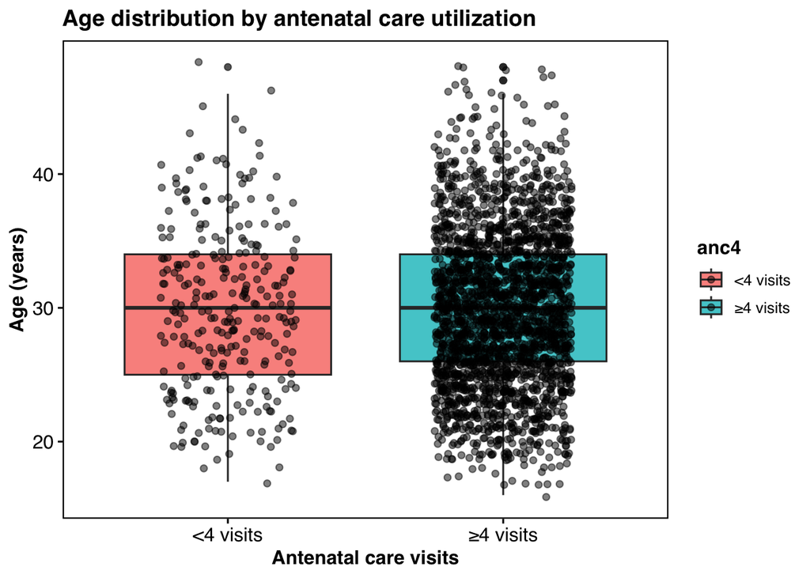

#### 3.2.2 Antenatal care utilization (≥4 visits) by maternal education level

The bar graph shows that the proportion of women with higher education level had higher antenatal care utilization 99.1% while lower proportion of women with no education had fewer antenatal care 74.6%.

Figure 2: Antenatal care utilization (≥4 visits) by maternal education level

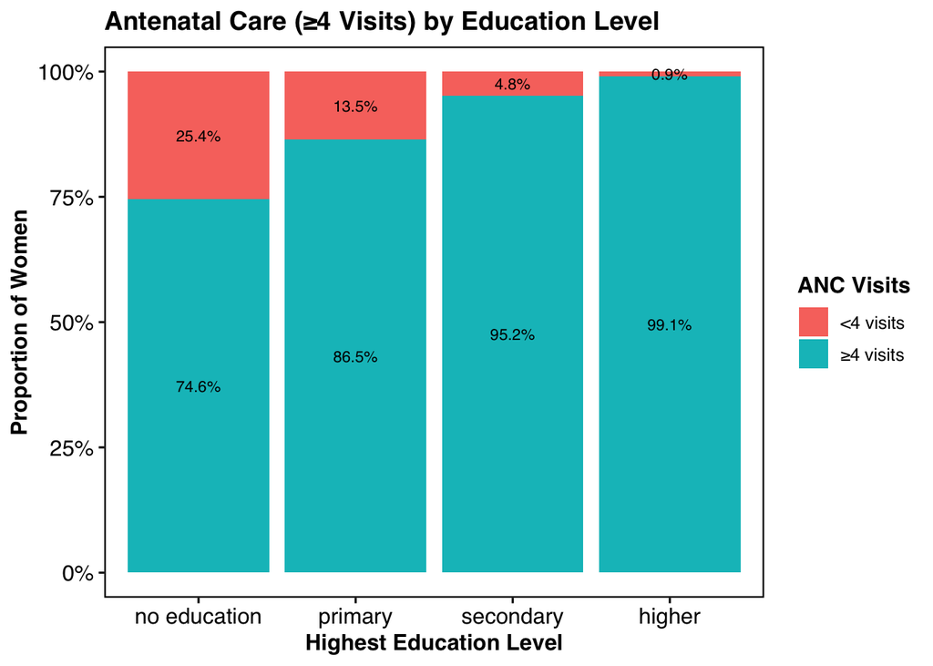

#### 3.2.3 Antenatal care by residence

The graph shows antenatal care (ANC) attendance (≥4 visits) between urban and rural women. Among women living in urban areas, the vast majority (93%) attended at least four antenatal care visits, while only 7% had fewer than four visits. In contrast, antenatal care attendance was lower among rural women, with 79% achieving four or more visits and 21% attending fewer than four visits.

Figure 3: Antenatal care by place of residence

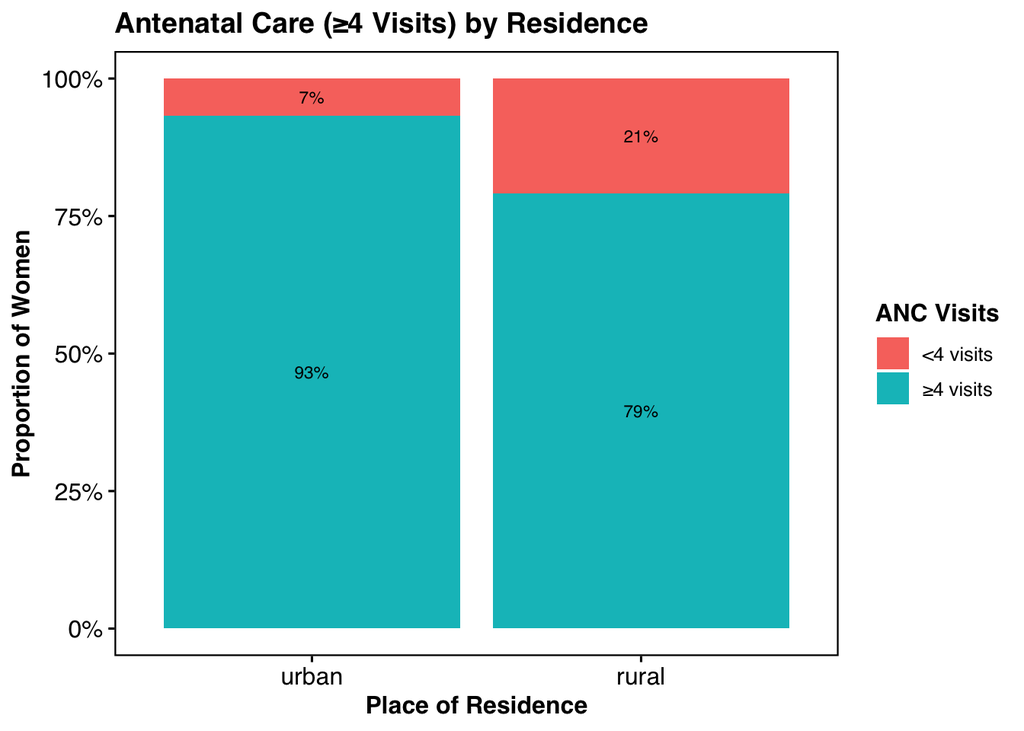

#### 3.2.4 Antenatal Care Utilization by Wealth Index

The distribution of antenatal care adherence (at least four visits) across wealth quintiles in Turkey is illustrated in Figure 4, based on the 2013 Demographic and Health Survey (DHS). The “richest” quintile achieved the highest rate of coverage at **98.5%**, while the “poorest” quintile had the lowest at **75.4%**. This represents a total disparity gap of **23.1 percentage points**.

Figure 4: wealth index and antenatal care utiliazation

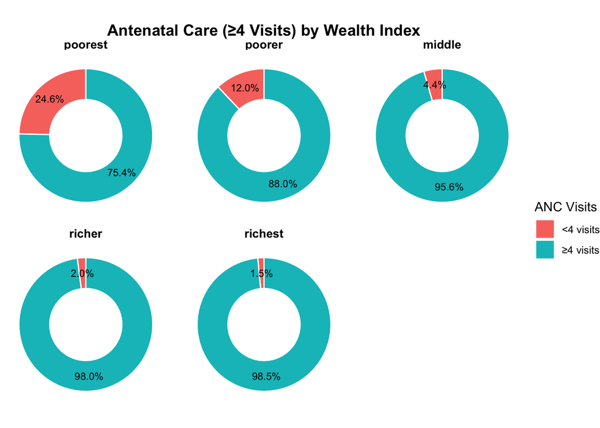

#### 3.2.5 Intranatal care utilization by maternal education level

Figure 5 illustrates a clear positive association between a woman’s educational attainment and the likelihood of receiving intranatal care. While utilization rates are high across all groups, significant disparities exist for those with the lowest levels of education. Women in the primary, secondary, and higher education groups have near-total utilization rates of 98.2%, 99.5%, and 99.4%, respectively. In contrast, women in the ‘no education’ group exhibit the lowest rate of utilization at 89.9%.

Figure 5: Intranatal care utilization and maternal education level

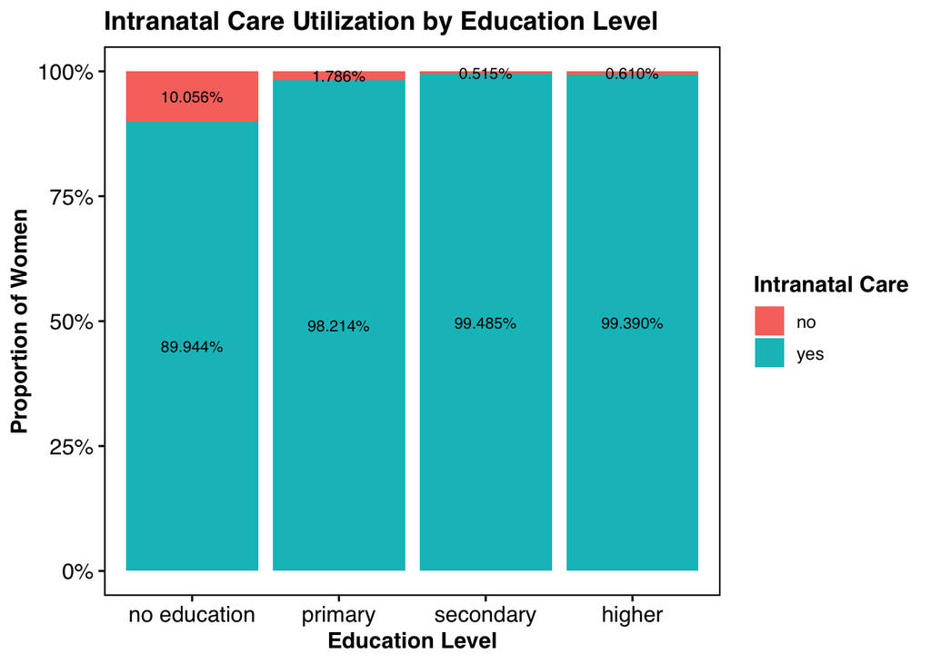

#### 3.2.6 Intranatal care by residence

The graph illustrates the disparity in intranatal care utilization between urban and rural women. Among those living in urban areas, the utilization rate is nearly universal at 99.0%. In contrast, utilization is notably lower among rural women, at 94.2%.

Figure 6: Intranatal care by place of residence

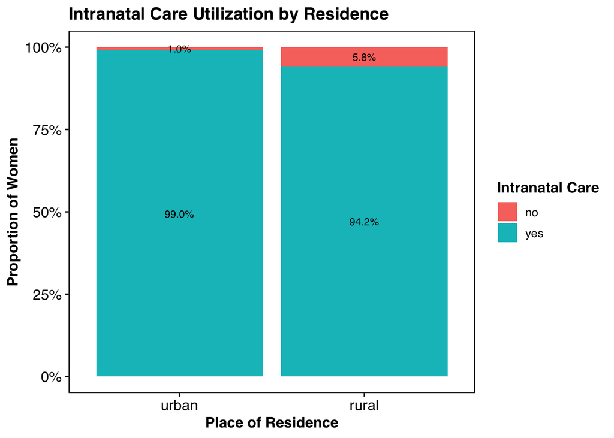

#### 3.2.7 Caesarean Section Delivery by Education Level

Figure 7: Caesarean section and maternal education

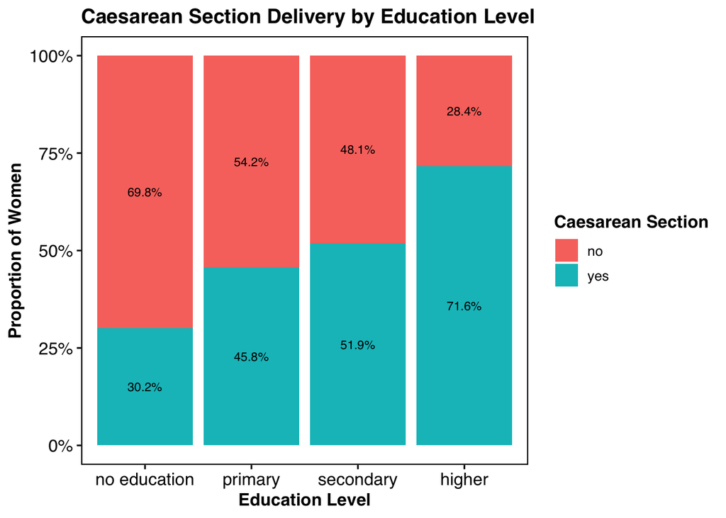

#### 3.2.8 Caesarean Section Delivery by Wealth Index

Figure 8: Caesarean section and wealth index

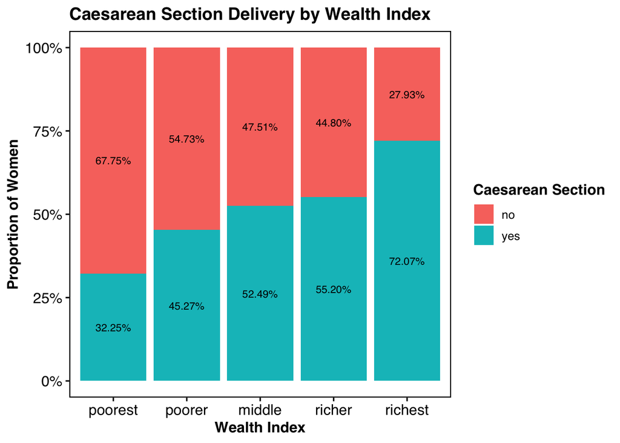

## 4 Conclusion

The analysis of the 2013 DHS data reveals that maternal healthcare utilization is primarily driven by socioeconomic factors rather than demographic variables like age. Household wealth and educational attainment are the strongest predictors of healthcare adherence. Women in the “poorest” quintile and those with no formal education face the greatest risk of receiving sub-optimal antenatal care, with a significant portion failing to reach the recommended four-visit threshold. Geographic location remains a significant factor in service utilization. Urban residents achieve substantially higher rates of antenatal care coverage at 93%, compared to 79% for their rural counterparts. Furthermore, urban residents achieve nearly universal intranatal care compared to those in rural areas.

A dramatic shift in delivery methods is evident as wealth and education increase. Caesarean sections have become the predominant delivery method for the wealthiest and most educated women—reaching rates above 70%—whereas vaginal delivery remains the norm for those with less education and fewer financial resources.

While Turkey has achieved high levels of maternal healthcare coverage, significant disparities persist. Policy efforts should focus on closing the gap for the most vulnerable populations—specifically women in the poorest households and those with no formal education—to ensure equitable access to essential maternal services.

## 5 Limitation

While this report provides significant insights into maternal healthcare trends, several limitations should be considered when interpreting the results:

Data Recency: The analysis utilizes data from the 2013 Demographic and Health Survey (DHS); consequently, the findings may not fully reflect the current healthcare landscape or recent policy changes in Turkey.

Focus on Quantity over Quality: The report evaluates the quantity of care (e.g., number of visits) and delivery methods but does not account for the clinical quality of the services, the specific content of care provided, or the medical necessity of Caesarean sections.

Weighting: All analyses in this report were conducted using unweighted data, which may affect the generalizability of the findings to the national population.

Unmeasured Confounders: Other potential confounding variables—such as health insurance status, geographic proximity to facilities, or specific medical histories were not analyzed in this report.

**A Heartfelt Thank You to the GRAPH Courses Instructors!**